# Meat and animal products consumption trends 2010–2020. Exploratory analysis

Tomasz Przechlewski

May 2023

# Introduction

Why we should eat less meat?

- Because [consumption] it is unhealthy
- Because [production] is economically inefficient
- Because [production] is harmful to environment

The last argument is very popular recently. We should eat less meat to save the Earth

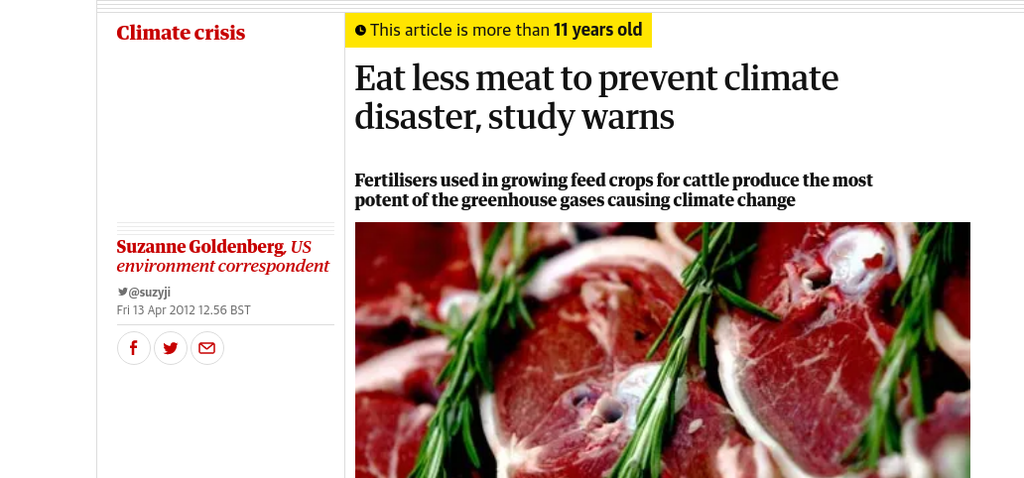

Note the publication date:

[figure not shown]

# Data

There is such a beast as FAO food balance sheet

Data on per capita supply at a retail level of various food items

Calculate as:

**(production + import + stocks) - (export + feeding/non-food-usage/wastage + closing stocks)**

The difference divided by population is per capita consumption

The balance is mantained from 1961 but in 2010 there was a methodology change

Up to you to assess the precision :-)

# FBS

Items (hundreds) and item groups (such as Meat or Animal Products)

Measured as:

- daily per capita energy supply (kcal/c/d or **kilocalories/per capita/daily**),
- daily per capita protein supply (g/c/d),
- daily per capita fat supply (g/c/d),

or

- daily per capita quantity supply (kg/c/year)

We use the following item groups: Meat, Animal Products (Meat + Eggs + Dairy products, Honey etc…), Total Products (ie. total per capita consumption)

https://www.fao.org/faostat/en/#data/FBS

# Results

We enhance FBS with GDP data from the World Bank and use World Bank Income Groups

GNI per capita, Atlas method (current USD) https://data.worldbank.org/indicator/NY.GNP.PCAP.CD

| GNI | Income Group |
| --- | --- |
| 0–1084 | low |
| 1085–4254 | lower-middle |
| 4255–13204 | upper-middle |
| 13205– | high |

We omit countries with population less than 3 mln.

There is 37 countries in high-income group; 31 countries in upper-middle-income group; 39 countries in lower-middle-income group and 31 countries in low-income group.

# Population

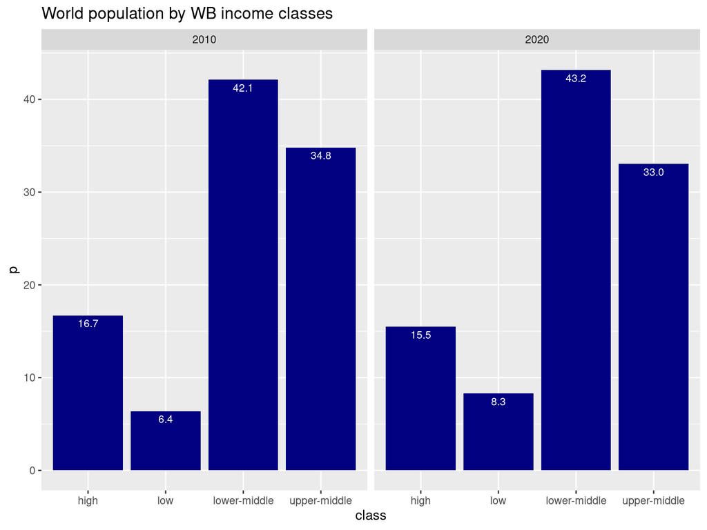

# Meat Consumption

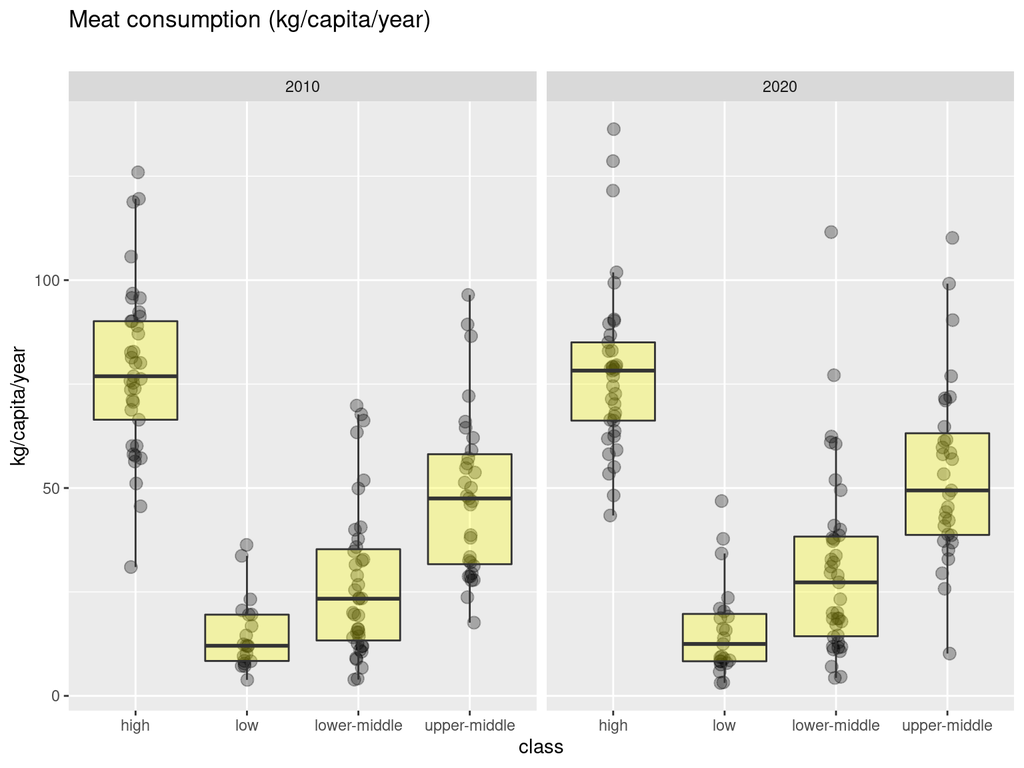

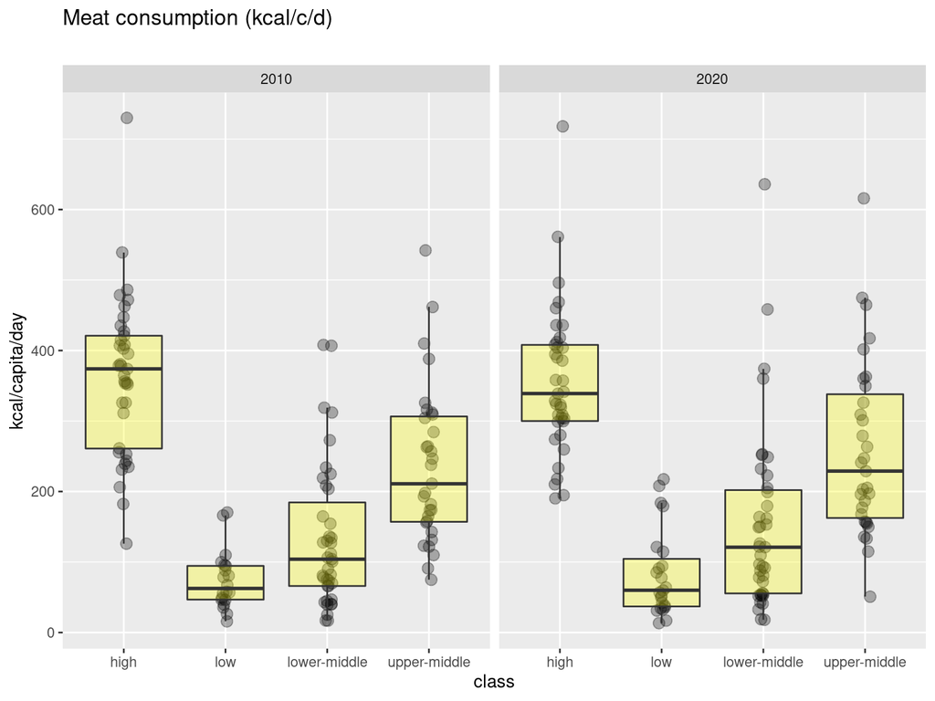

# Animal Products consumption

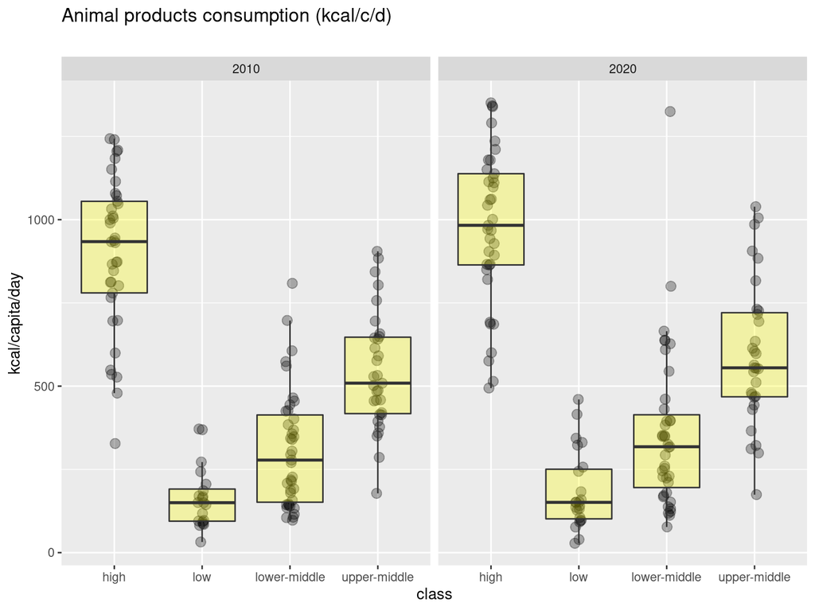

# Total consumption

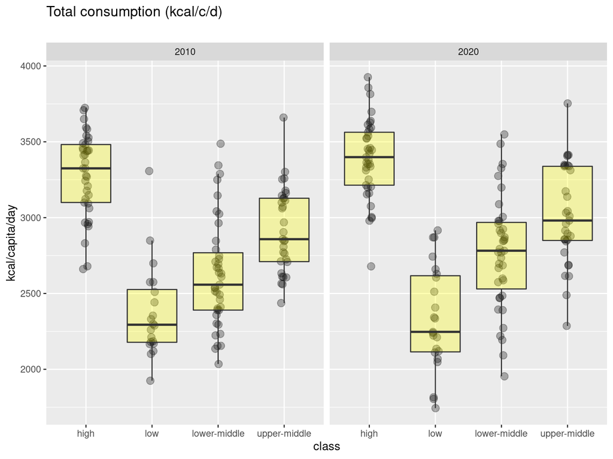

# Protein supply

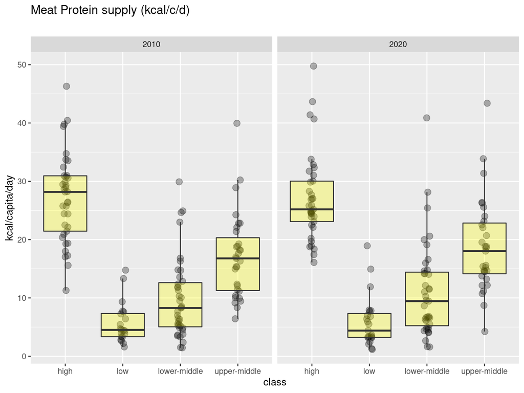

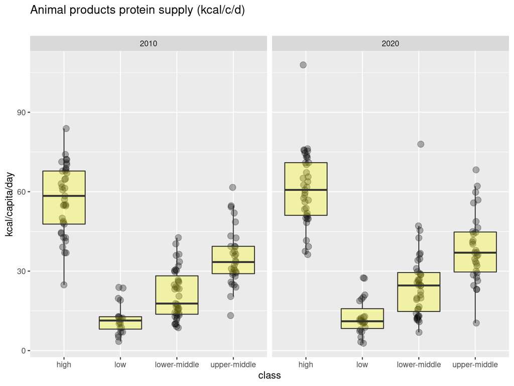

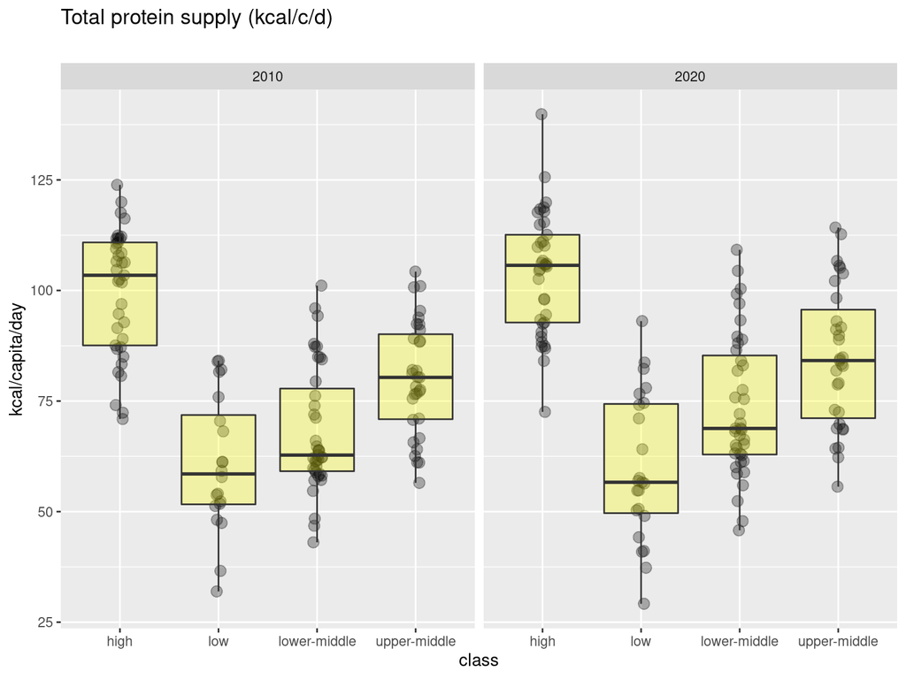

# Total Consumption of meat

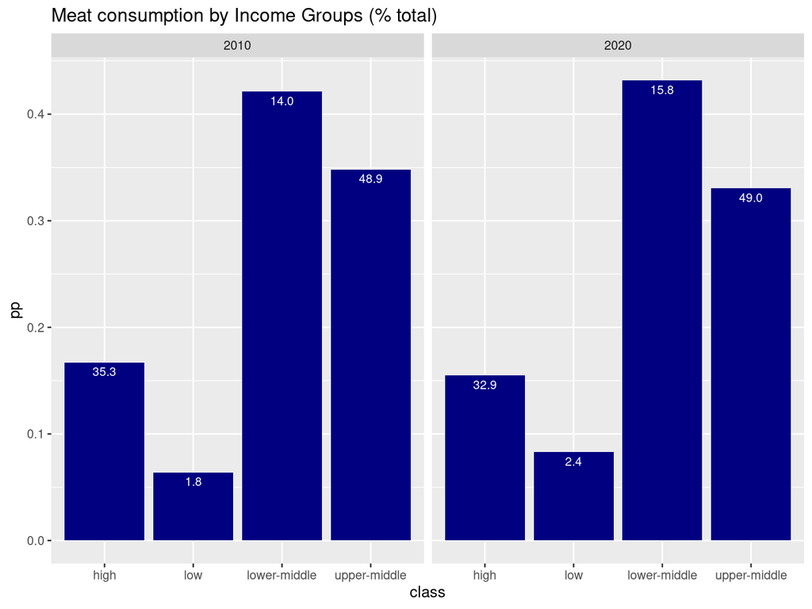

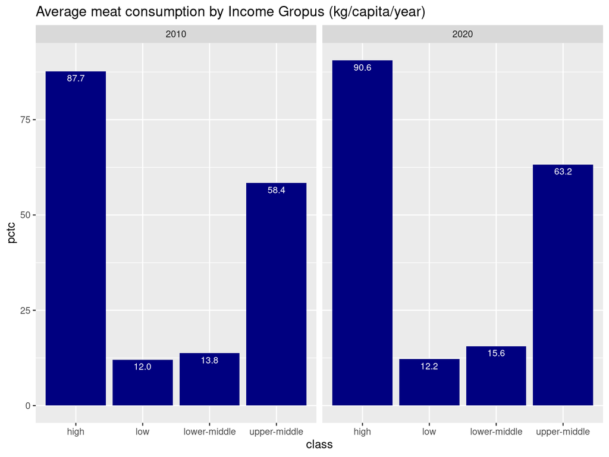

# Total Consumption of Animal products

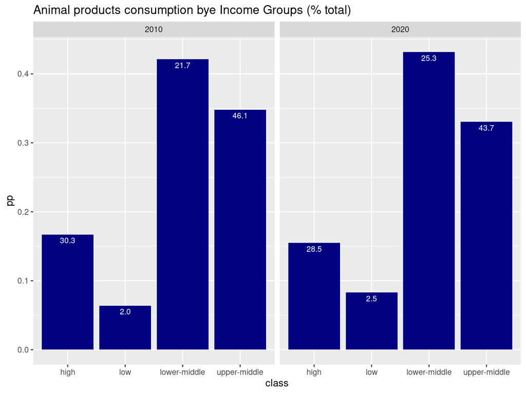

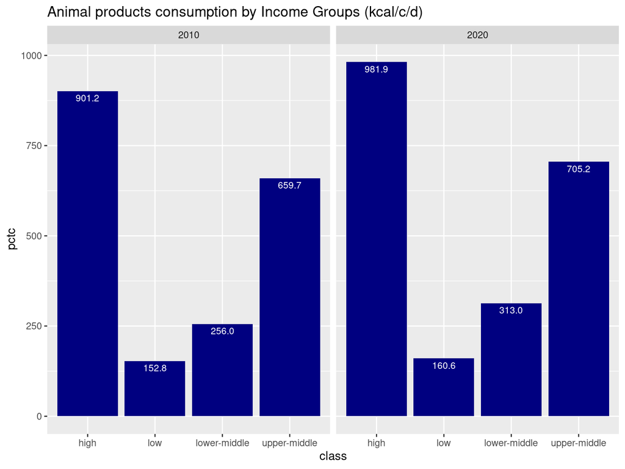

# Total consumption

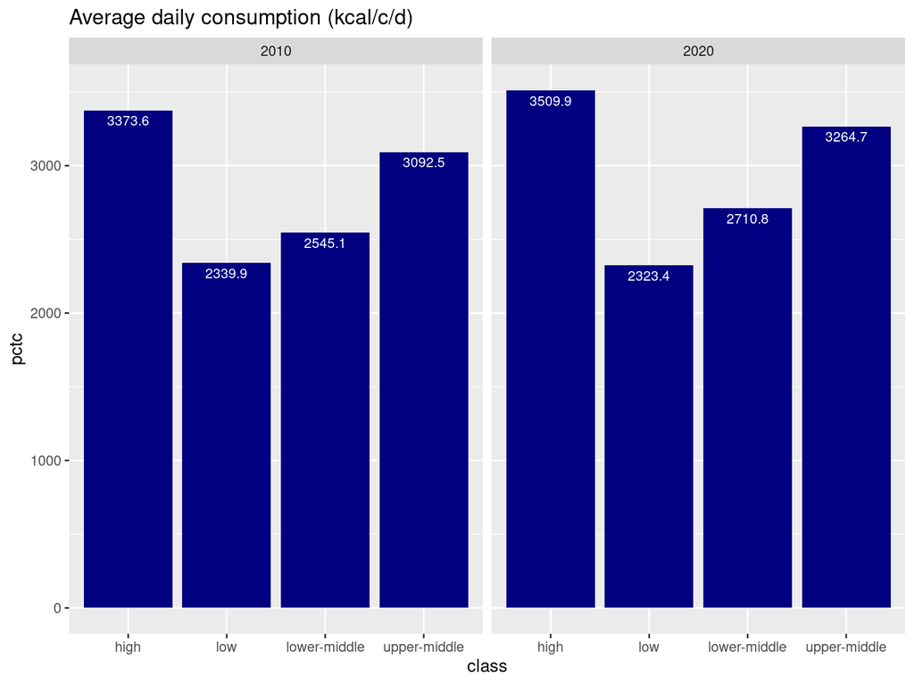

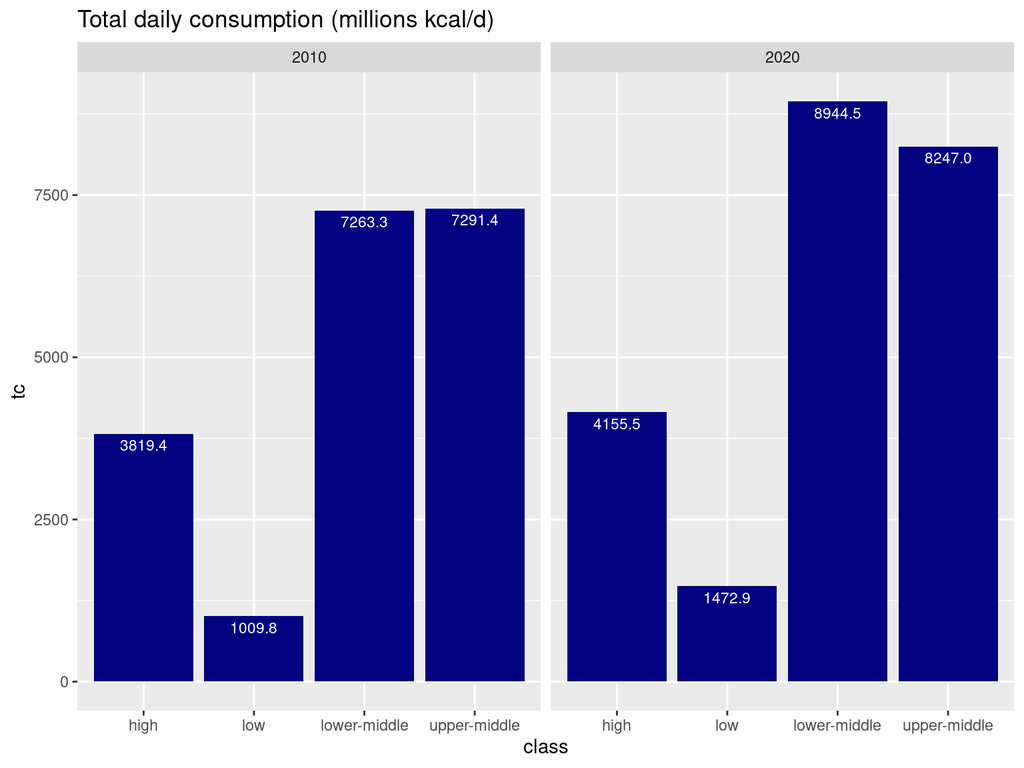

# Energy supply by food category

| Group | Year | Meat | AnimalP | Total | Meat%† | AnimalP%† |
| --- | --- | --- | --- | --- | --- | --- |
| high | 2010 | 370.9 | 901.2 | 3373.6 | 11.0 | 26.7 |
| high | 2020 | 401.8 | 981.9 | 3509.9 | 11.4 | 28.0 |
| low | 2010 | 62.7 | 152.8 | 2339.9 | 2.7 | 6.5 |
| low | 2020 | 65.7 | 160.6 | 2323.4 | 2.8 | 6.9 |
| lower-middle | 2010 | 70.2 | 256.0 | 2545.1 | 2.8 | 10.1 |
| lower-middle | 2020 | 77.5 | 313.0 | 2710.8 | 2.9 | 11.5 |
| upper-middle | 2010 | 385.7 | 659.7 | 3092.5 | 12.5 | 21.3 |
| upper-middle | 2020 | 399.6 | 705.2 | 3264.7 | 12.2 | 21.6 |

† percent of total energy supply (kcal/c/d)

# Per capita vs total

This is called **marimekko plot** (total consumption of meat (kg/c/y) by per capita consumption)

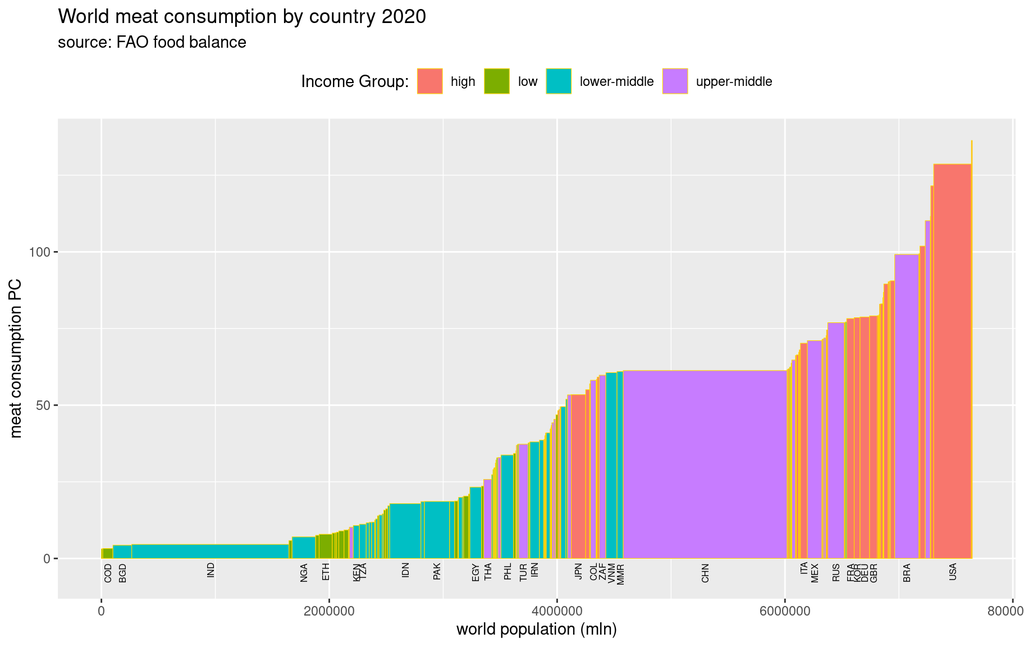

MMR – Myanmar

# Schabowy Raz

Kotlet schabowy (KOHT-let s-HA-bow-vey): in its most traditional form, this pork cutlet is coated with breadcrumbs, fried on lard, and served with potatoes and browned or pickled cabbage. https://culture.pl/en/work/polish-food-101-kotlet-schabowy

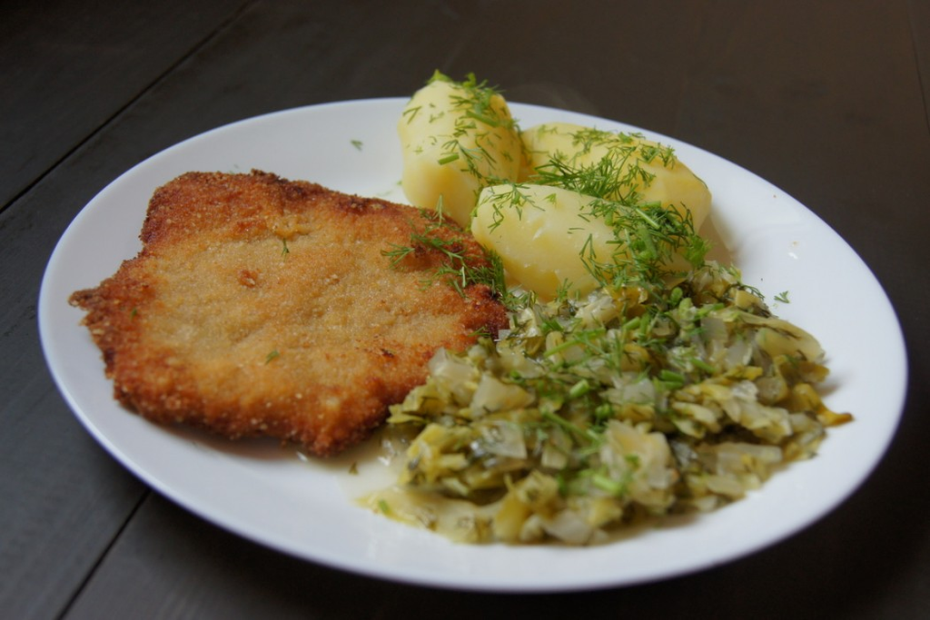

Non-halal in classical form but poultry variant is also popular

And do not forget about *kiełbasa* (sausage)

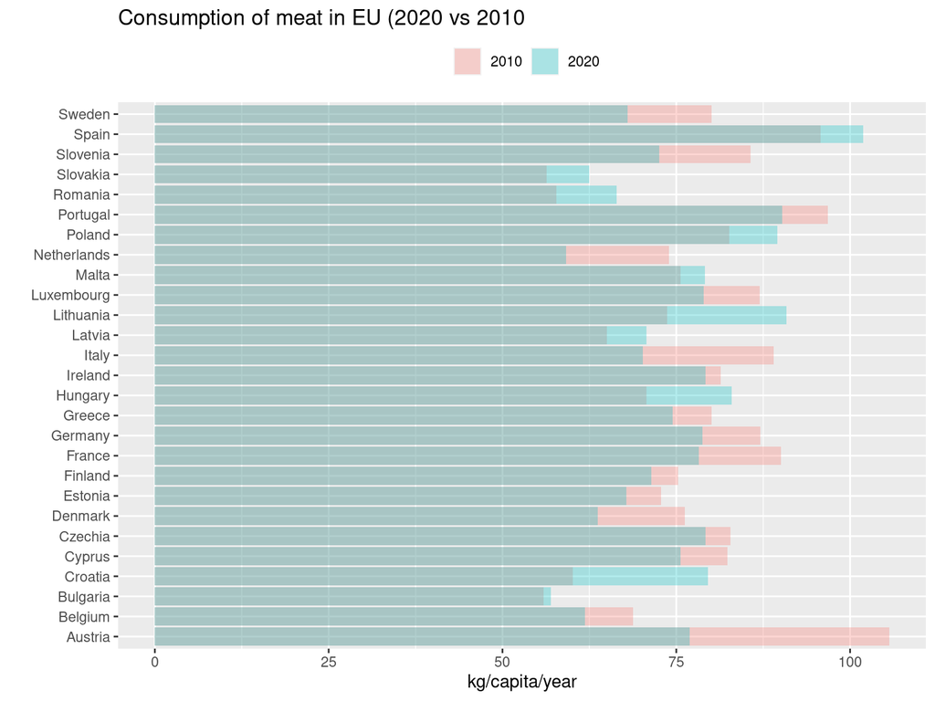

PL/POL meat consumption: 82.62 (2010) vs 89.52 (2020) kg/pc/year

# Environmental Kuznets Curve

The environmental Kuznets curve (EKC) is a hypothesized relationship between various indicators of environmental degradation and per capita income.

In the early stages of economic growth, pollution emissions increase and environmental quality declines, but beyond some level of per capita income the trend reverses, so that at high income levels, economic growth leads to environmental improvement.

https://www.sciencedirect.com/topics/earth-and-planetary-sciences/environmental-kuznets-curve

In case of meat consumption and the most basic form the relation can be specified as:

Meat = a + b · GDP + c · GDP²

If a relation between Meat consumption and GDP follows EKC it must has a turning point, ie. an income level above which the consumption of meat decreases.

BTW: https://www.youtube.com/watch?v=2-LunSug43 (How to pronounce Kuznets)

# Environmental Kuznets Curve cd

Simple regressions

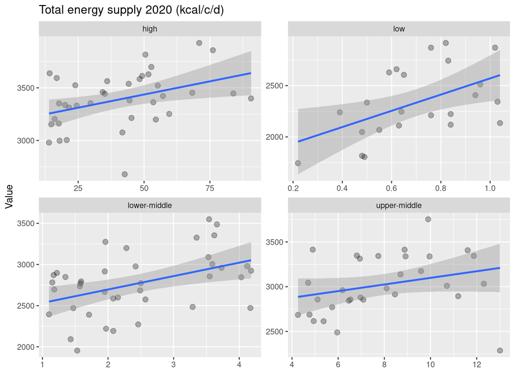

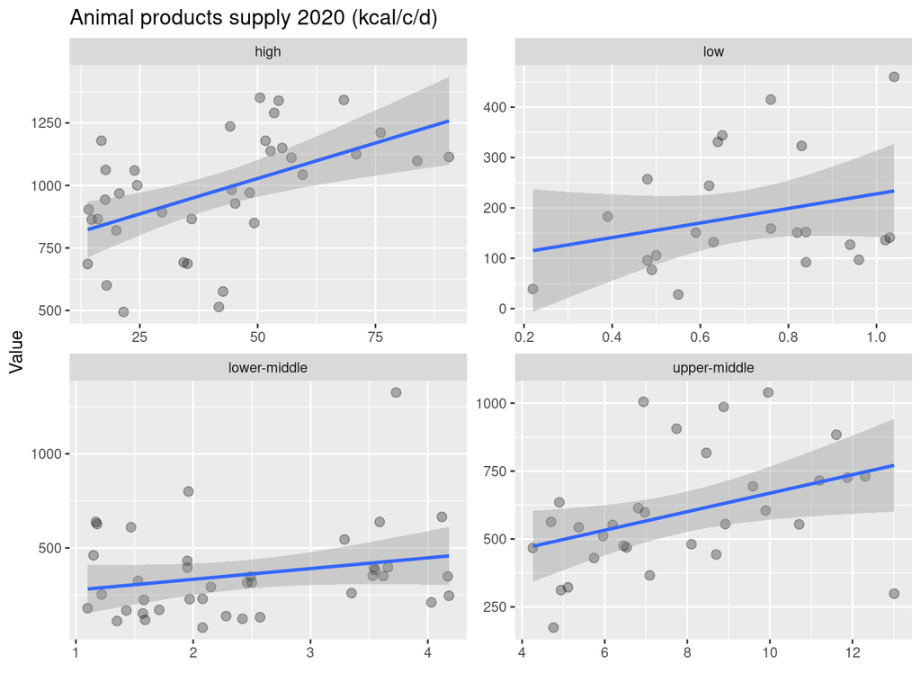

# EKC, linear regression

GDP/GNI per capita (GDP NY.GNP.PCAP.CD) versus **Animal products supply 2020 (kcal/c/d)**

Linear regression: Meat = a + b · GNI

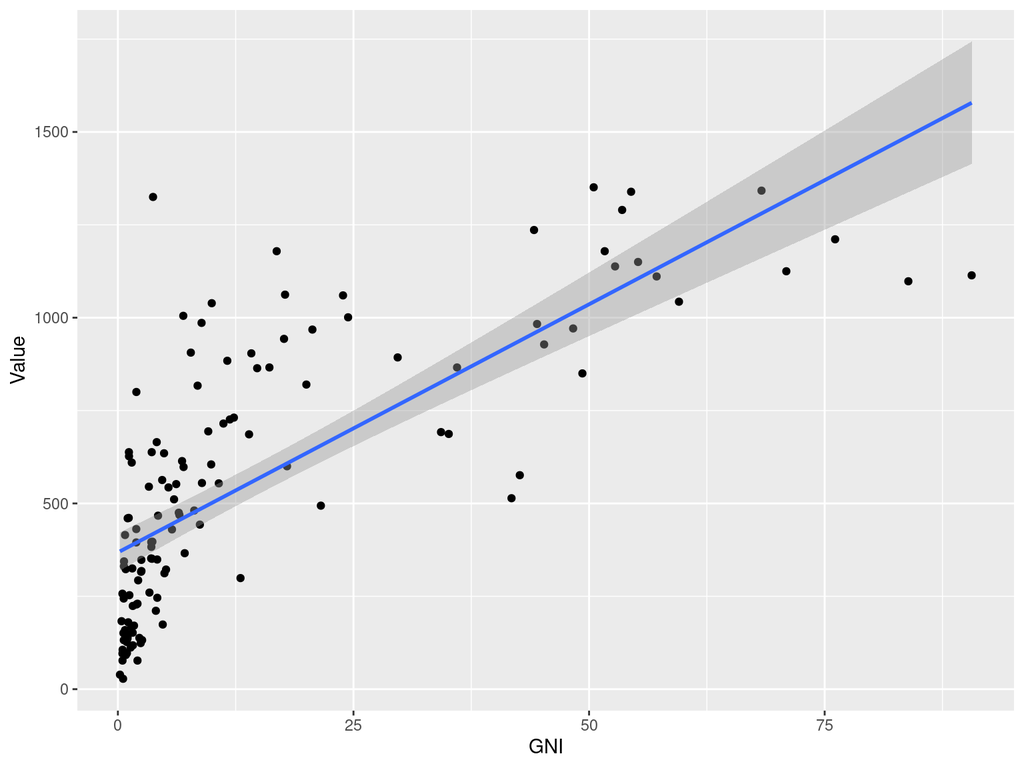

Meat = 368.0 + 13.4 GNI (1000 USD/pc; R² = 55.6)

# EKC, polynominal (quadratic) regression

Meat = a + b · GDP + c · GDP²

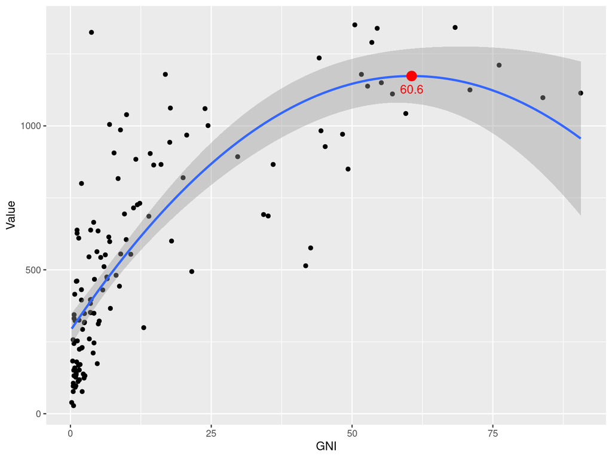

Apex point is 1173.3 kcal/c/daily of Animal Products at 60.6 (thousand) USD/pc.

# Conclusion

We are doomed

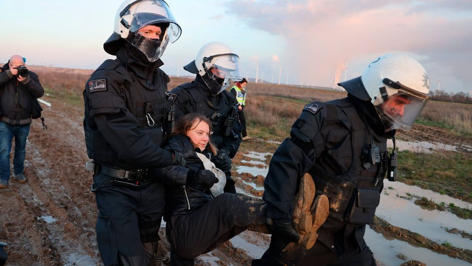

# Bibliography

Sans P., Combris P., *World meat consumption patters: An overview of the last fifty years (1961–2011)* Meat Science 2015

Przechlewski T., *Meat and animal products consumption trends 2010–2020. Exploratory analysis* Oblicza Dobrobytu 2023 (In Press) https://github.com/hrpunio/Papers/tree/main/PSW_2023

# Appendix

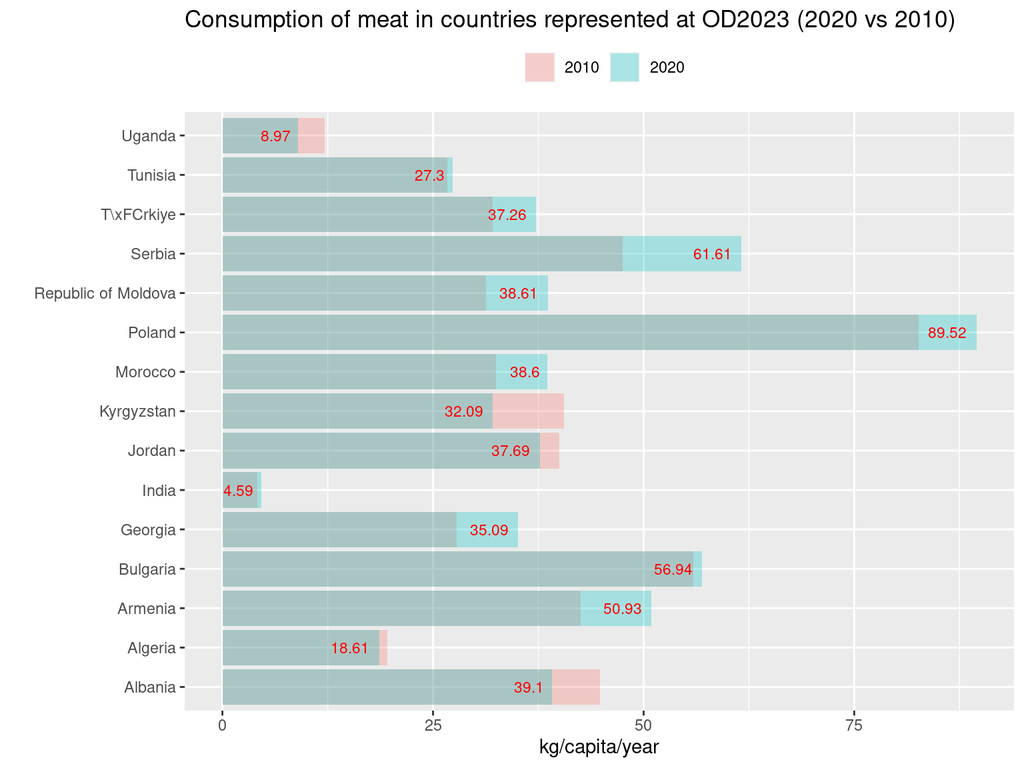

Thank you (finally)